# Indian household heads: women or men?

Luke Wolcott

June 4, 2017

Continuing with the Indian NFHS-3 dataset from [last week](https://lukewolcott.github.io/InTheResistance/Week19/NFHS-DHS-V.html), now I’m interested in the variable HV219, which asks, “Is the head of the household male or female?”

First I look at the difference between male- and female-led households, and then I build an algorithm that predicts the sex of the HH head from household characteristics.

### Differences in male- and female-led households

I’m using the same cleaned dataset from last week, based on the 109,041 questionnaire responses about Indian households. In last week’s report I listed the 44 household characteristic variables that I’m looking at.

First, a table of the HV219 variable shows that only 14.37 percent of households have women heads.

```
##
##   Male Female
##  92446  15516
```

The first piece of good news is that there is not much difference in the distribution of HV270, the “Wealth Index”, between the two types of household.

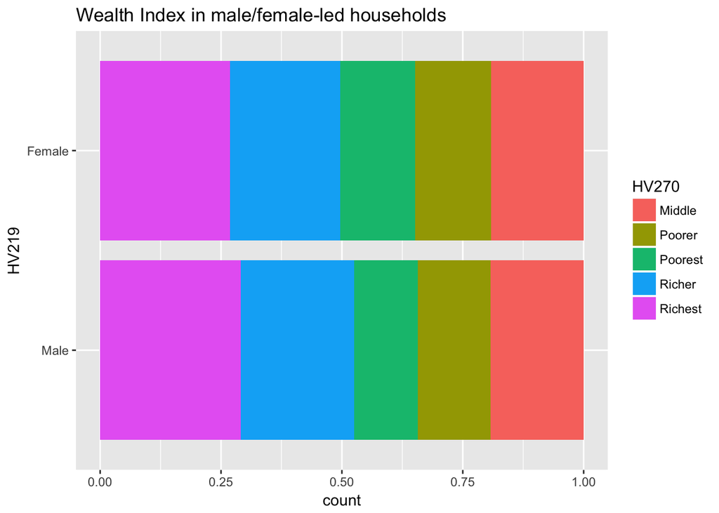

A quick way to look for differences between male- and female-led households is to compare the mean value of the “does not have / does have” variables.

```
##    HV219 HV025 HV206 HV207 HV208 HV209 HV210 HV211  HV212 HV221 HV227
## 1   Male 0.536 0.791 0.364 0.551 0.230 0.474 0.218 0.0505 0.192 0.382
## 2 Female 0.558 0.763 0.313 0.494 0.218 0.302 0.141 0.0358 0.185 0.359
##   HV243A HV243B HV243C HV246   SH30 SH47B SH47C SH47D SH47E SH47F SH47G
## 1  0.246  0.839 0.0431 0.440 0.0195 0.666 0.526 0.643 0.847 0.562 0.606
## 2  0.203  0.756 0.0132 0.338 0.0151 0.629 0.485 0.623 0.814 0.538 0.550
##   SH47I SH47J SH47K  SH47N  SH47U   SH47V   SH47W SH56A SH56B SH56C SH56D
## 1 0.220 0.359 0.251 0.0522 0.1033 0.01206 0.01501 0.741 0.257 0.217 0.365
## 2 0.181 0.337 0.222 0.0410 0.0821 0.00554 0.00567 0.740 0.255 0.207 0.366
##    SH58 SH62A   SH62B   SH62C  SH62D  SH62E SH62F SHSTRUC
## 1 0.841 0.318 0.00433 0.00561 0.1172 0.0143 0.178   0.381
## 2 0.835 0.191 0.00232 0.00258 0.0878 0.0098 0.159   0.430
```

We can pick out a few of these to look at histograms.

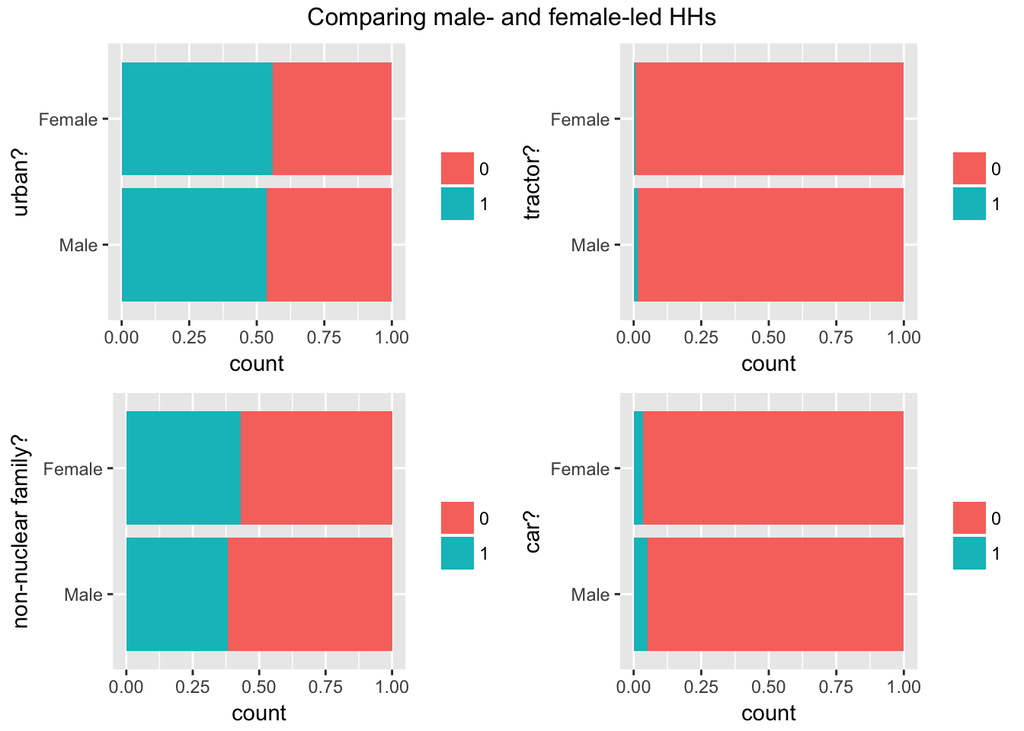

### Predicting who’s in charge

From our cleaned dataset of 107962 households with 44 characteristic variables, we want to build an algorithm that will predict HV219: whether the head of the household is male or female.

The factor variables have been converted into 0/1s, and the numeric variables (number in household, number of children, number of rooms for sleeping) have been scaled to have mean 0 and standard deviation 1.

A good first try would be with a logistic regression.

We can check how the model predicts on the test dataset.

```
## Confusion Matrix and Statistics
##
##           Reference
## Prediction     0     1
##          0 18383  3091
##          1    48    71
##
##                Accuracy : 0.85463
##                  95% CI : (0.84986, 0.85931)
##     No Information Rate : 0.85356
##     P-Value [Acc > NIR] : 0.33314
##
##                   Kappa : 0.03301
##  Mcnemar's Test P-Value : < 2e-16
##
##             Sensitivity : 0.997396
##             Specificity : 0.022454
##          Pos Pred Value : 0.856058
##          Neg Pred Value : 0.596639
##              Prevalence : 0.853564
##          Detection Rate : 0.851341
##    Detection Prevalence : 0.994489
##       Balanced Accuracy : 0.509925
##
##        'Positive' Class : 0
##
```

This is pretty bad. Our algorithm is almost always predicting “Male”, and we can’t be confident it will do better than just guessing “Male” every time.

Let’s try with a tree:

```
## Confusion Matrix and Statistics
##
##           Reference
## Prediction  Male Female
##     Male   18176   2666
##     Female   255    496
##
##                Accuracy : 0.86472
##                  95% CI : (0.86009, 0.86926)
##     No Information Rate : 0.85356
##     P-Value [Acc > NIR] : 1.4531e-06
##
##                   Kappa : 0.20906
##  Mcnemar's Test P-Value : < 2.22e-16
##
##             Sensitivity : 0.98616
##             Specificity : 0.15686
##          Pos Pred Value : 0.87209
##          Neg Pred Value : 0.66045
##              Prevalence : 0.85356
##          Detection Rate : 0.84175
##    Detection Prevalence : 0.96522
##       Balanced Accuracy : 0.57151
##
##        'Positive' Class : Male
##
```

Still very bad, but at least it is reliably better than the No Information Rate. Let’s see if a random forest model can do better:

```
## Confusion Matrix and Statistics
##
##           Reference
## Prediction  Male Female
##     Male   18268   2725
##     Female   163    437
##
##                Accuracy : 0.86625
##                  95% CI : (0.86164, 0.87077)
##     No Information Rate : 0.85356
##     P-Value [Acc > NIR] : 4.975e-08
##
##                   Kappa : 0.19471
##  Mcnemar's Test P-Value : < 2.22e-16
##
##             Sensitivity : 0.99116
##             Specificity : 0.13820
##          Pos Pred Value : 0.87019
##          Neg Pred Value : 0.72833
##              Prevalence : 0.85356
##          Detection Rate : 0.84601
##    Detection Prevalence : 0.97221
##       Balanced Accuracy : 0.56468
##
##        'Positive' Class : Male
##
```

This is better, but not by much. It seems that we’re going to have to engineer better features if we want to do better. But finally, let’s try some boosting to see if that does something magical:

```
## Confusion Matrix and Statistics
##
##           Reference
## Prediction  Male Female
##     Male   18227   2673
##     Female   204    489
##
##                Accuracy : 0.86676
##                  95% CI : (0.86216, 0.87127)
##     No Information Rate : 0.85356
##     P-Value [Acc > NIR] : 1.471e-08
##
##                   Kappa : 0.21222
##  Mcnemar's Test P-Value : < 2.22e-16
##
##             Sensitivity : 0.98893
##             Specificity : 0.15465
##          Pos Pred Value : 0.87211
##          Neg Pred Value : 0.70563
##              Prevalence : 0.85356
##          Detection Rate : 0.84412
##    Detection Prevalence : 0.96791
##       Balanced Accuracy : 0.57179
##
##        'Positive' Class : Male
##
```

### Better features for better prediction

This first pass at a household head prediction algorithm was naively hopeful that simply counting things like beds, windows, bicycles, cows, and tractors in a household might allow me to predict who was in charge. For better or for worse, the model needs more nuance.

A good first place to look would be at the role of the scaled numerical variables (# in household, # of children, # of rooms for sleeping, age of HH head) versus the 0/1 categorical variables. Does the scaling affect the model performance?